# Введение

Как правило, виды, имеющие сходную экологическую нишу, будут конкурировать за использование какого-либо ресурса. Согласно принципу Гаузе, в такой системе возможно несколько вариантов событий: один вид будет вытеснен другим или произойдет разделение экологических ниш (Gause 1934). Например, птицы с менее эффективным способом добывания пищи стремятся занять местообитания видов с менее энергозатратным способом. Однако в таком случае они оказываются вытеснены на старую территорию (Хлебосолов 2002).

Конкурентные взаимоотношения характерны и для бентоса. Одним из таких примеров являются взаимоотношения *Mytilus trossulus* и *Mytilus edulis*. Эти криптические виды прикрепляются к твердым субстратам, оба являются фильтраторами, при этом способны образовывать смешанные поселения (Буфалова et al. 2005), в том числе в Белом море (Katolikova et al. 2016). Поскольку *Mytilus trossulus* и *Mytilus edulis* близкие виды, в смешанных поселениях можно ожидать появления межвидовой конкуренции. На это указывает, например, то, что в таких поселениях смертность мидий зависит от их плотности, тогда как в однородных популяциях такой зависимости не наблюдается (Шилонцев 2022). Кроме того, рост раковины *Mytilus edulis* происходит медленнее, если в поселении преобладает *Mytilus trossulus* (Ковалев 2023). *Mytilus edulis* способны подавлять другой вид, они чаще прикрепляют биссус к особям *Mytilus trossulus* (Шеламова 2022). В плотных поселениях возрастает значимость и внутривидовой конкуренции. Так, *Mytilus trossulus* способны образовывать взаимный биссус, проникающий из буссусной железы одного моллюска в железу другого. Чаще такое явление появляется в парах, где присутствуют только моллюски этого вида (Шеламова 2023).

Однако конкуренция может проявляться не только в различных механизмах подавления конкурента, но и в разделении экологических ниш. Так известно, что *Mytilus edulis* чаще встречаются на грунте, в то время как *Mytilus trossulus* предпочитают фукоиды (Katolikova et al. 2016). Такое разделение может быть связано как с предпочтением определенного субстрата каждым видом, так и с вытесненением *Mytilus trossulus* на фукоиды вследствие конкуренции. Если второе предположение верно, то доля прикрепившихся к водорослям *Mytilus trossulus* будет возрастать по мере увеличения плотности поселения.

В этой работе мы предположили, что обилие *Mytilus trossulus* на фукоидах будет возрастать по мере увеличения плотности поселения.

# Материалы и методы

## Идентификация мидий

В работе мы использовали разделение мидий на два морфотипа по полосе конхеалиноваго слоя рядом с лигаментом. Т-морфотип соответствовал *Mytilus trossulus*, E-морфотип – *Mytilus edulis* (Khaitov et al. 2021).

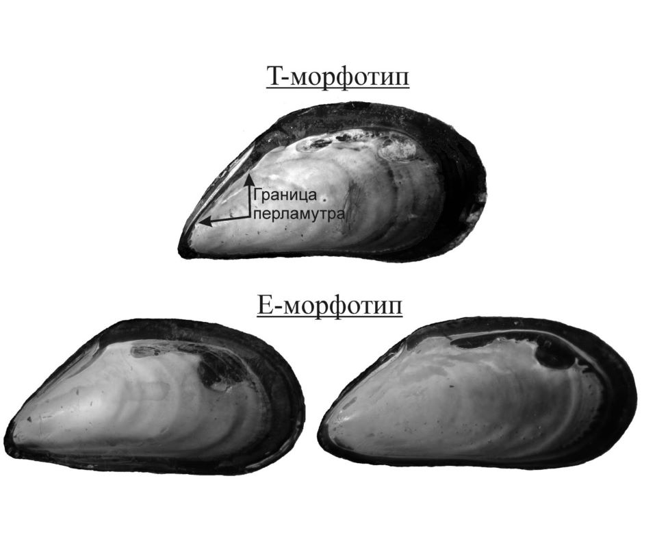

Рис. 1. Морфотипы мидий

## Сбор материала

Мидии разных морфотипов собирались с разных точек. Т-морфотип был собран на литорали острова Кордоша. Мидии брались с фукоидов. Е-морфотип собрали с мидиевой банки IIR. Собирались мидий, образующих друзы на дне. Были отобраны моллюски размером 15-25 мм. До эксперимента они находились в ведрах с водой. Воду меняли несколько раз в день. За три дня до эксперимента мидии были помещены в сетки на литорали. *Fucus vesiculosus* и *Ascophyllum nodozum* были собраны на острове Семеновец 12 июля. Пучки срезали, отделяя базальный диск от субстрата. В тот же день они были очищены от обрастателей.

## Снятие и обработка

Эксперимент снят 13 августа. Из контейнеров доставили пучки *Fucus vesiculosus* и *Ascophyllum nodozum* с прикрепленными на них мидиями, а также собирали мидий со дна садка. При разборке материала садков мы аккуратно отделяли водоросли от садка так, чтобы моллюски (как живые, так и мертвые) оставались в пределах той части экспериментальной установки, где они находились на момент снятия экспермента. Таким образом, содержимое садков было разделено на три группы: материал, представленный на Fucus, материал, представленный на Ascophyllum, и материал, представленный на дне садка (далее, на грунте). Затем мидий разделяли внутри каждой группы на мертвых и живых, подсчитывали. При этом мы учитывали только тех моллюсков, которые подходили под размер отобранных при постановке эксперимента (15-25 мм). Створки мертвых мидий сушили, створки живых мидий очищали от мягких тканей и сушили. Затем определяли морфотип мидии.

## Статистическая обработка

Для обработки данных мы использовали язык статистического программирования R (R Core Team 2023). Мы определяли численность на момент конца эксперимента, при этом учитывали живых и мертвых моллюсков. На основе этой величины садки разделили на три группы: низкая, средняя и высокая плотность поселения. Был определен таксономический состав (процент мидий T-морфотипа).

Для определения влияния таксономической структуры на выбор субстрата была построена модель GAM. В качестве предикторов была взята таксономическая структура, вес фукоидов, плотность поселения. На основе той же модели была проанализирована вероятность гибели мидий. В этом случае в качестве факторов выступал таксономический состав, плотность, вес водорослей, морфотип. Кроме того, была введена величина Diff, представляющая собой разность между долей Т-морфотипа на грунте и на фукоидах. Для неё также была построена модель GAM с такими же предикторами. Рассматривалась зависимость Diff от таксономической структуры, веса фукоидов и плотности поселения.

# Результаты

## Влияние таксономической структуры на вероятность выбора в качестве субстрата фукоидов

Табл. 1. Результаты анализа модели. Density medium - средняя плотность, Density Nigh - высокая. За базовый уровень принята низкая плотность

| term | estimate | std.error | statistic | p.value |
| --- | --- | --- | --- | --- |
| (Intercept) | 1.2231315 | 0.3726093 | 3.2826114 | 0.0010285 |
| DensityMedium | 0.1990246 | 0.4461213 | 0.4461221 | 0.6555091 |
| DensityNigh | 0.5477180 | 0.4056643 | 1.3501755 | 0.1769597 |

Табл. 2. Результаты анализа вероятности выбора фукоидов в качестве субстрата. Prop_T - таксономическая структура, B_Algae - вес водорослей. Остальные обозначения аналогичны таблице 1.

| term | edf | ref.df | statistic | p.value |
| --- | --- | --- | --- | --- |
| s(Prop_T):DensityLow | 1.000004 | 1.000009 | 0.0196037 | 0.8886610 |
| s(Prop_T):DensityMedium | 1.744520 | 2.020558 | 7.7498558 | 0.0218105 |
| s(Prop_T):DensityNigh | 3.440990 | 3.738407 | 18.2318897 | 0.0089430 |
| s(B_Algae):DensityLow | 1.000015 | 1.000030 | 0.1359177 | 0.7123936 |
| s(B_Algae):DensityMedium | 1.793855 | 2.165913 | 11.1661549 | 0.0054432 |
| s(B_Algae):DensityNigh | 3.002043 | 3.314002 | 5.0649047 | 0.1219372 |

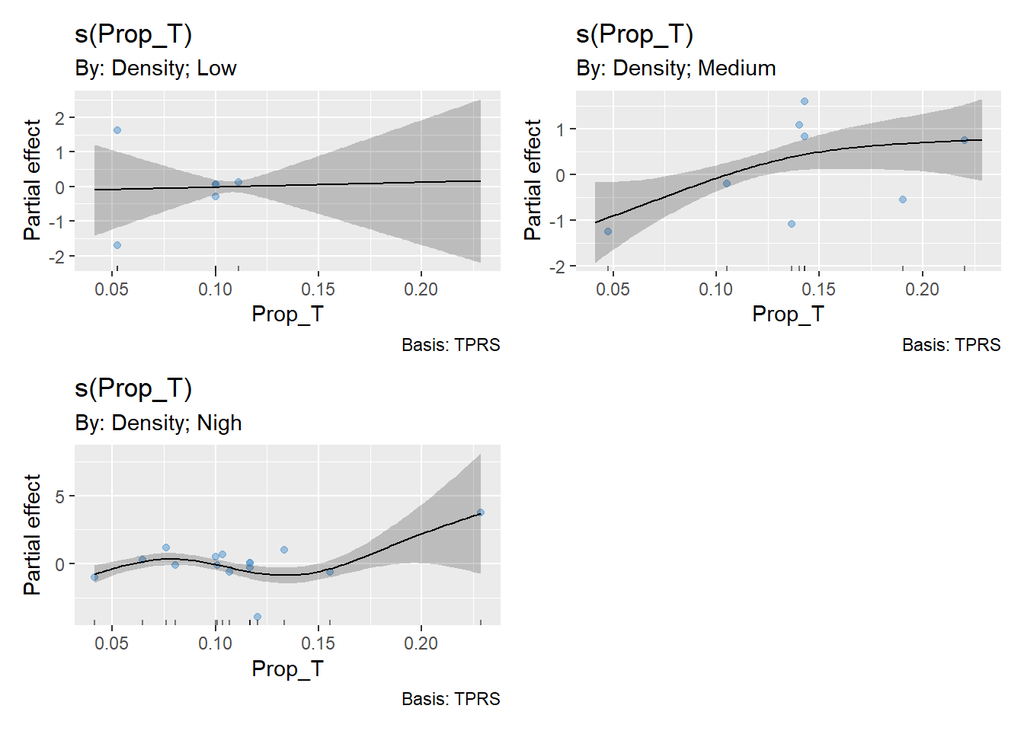

## Влияние таксономической структуры на изменение величины Diff

| term | estimate | std.error | statistic | p.value |
| --- | --- | --- | --- | --- |
| (Intercept) | 0.2077684 | 0.2882337 | 0.7208333 | 0.4810973 |
| DensityMedium | -0.1730875 | 0.2893000 | -0.5982975 | 0.5577626 |
| DensityNigh | -0.1627615 | 0.2885619 | -0.5640436 | 0.5803082 |

| term | edf | ref.df | statistic | p.value |
| --- | --- | --- | --- | --- |
| s(Prop_T):DensityLow | 1.157268 | 1.191974 | 2.497073 | 0.3068325 |
| s(Prop_T):DensityMedium | 1.966796 | 1.998448 | 14.017506 | 0.0002421 |
| s(Prop_T):DensityNigh | 1.000000 | 1.000001 | 16.360136 | 0.0008407 |
| s(B_Algae):DensityLow | 2.727140 | 2.904833 | 6.075898 | 0.0080633 |
| s(B_Algae):DensityMedium | 1.642343 | 1.996614 | 1.472269 | 0.2699136 |
| s(B_Algae):DensityNigh | 1.000001 | 1.000002 | 0.989501 | 0.3338144 |

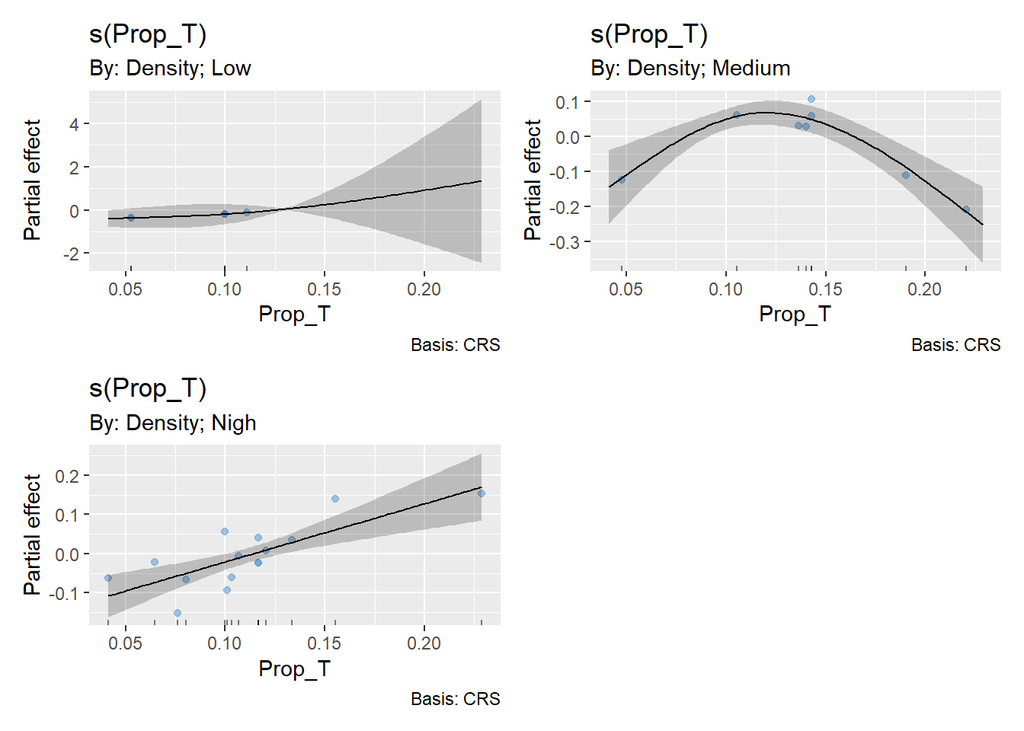

## Влияние таксономической структуры на гибель мидий

| term | estimate | std.error | statistic | p.value |
| --- | --- | --- | --- | --- |
| (Intercept) | -1.9991992 | 0.6117410 | -3.2680485 | 0.0010829 |
| DensityMedium | 0.3750672 | 0.6338237 | 0.5917532 | 0.5540158 |
| DensityNigh | 0.2476389 | 0.6180204 | 0.4006970 | 0.6886433 |
| MorphotypeT | 0.7282950 | 0.1782951 | 4.0847721 | 0.0000441 |

| term | edf | ref.df | statistic | p.value |
| --- | --- | --- | --- | --- |
| s(Prop_T):DensityLow | 1.000029 | 1.000052 | 0.2083082 | 0.6480834 |
| s(Prop_T):DensityMedium | 1.000032 | 1.000064 | 1.5398458 | 0.2146577 |
| s(Prop_T):DensityNigh | 1.000221 | 1.000371 | 5.2592509 | 0.0218030 |
| s(B_Algae):DensityLow | 1.729367 | 2.079445 | 1.9944896 | 0.3837088 |
| s(B_Algae):DensityMedium | 1.000442 | 1.000884 | 0.0401183 | 0.8422972 |
| s(B_Algae):DensityNigh | 2.941473 | 3.492430 | 6.8995872 | 0.0763854 |

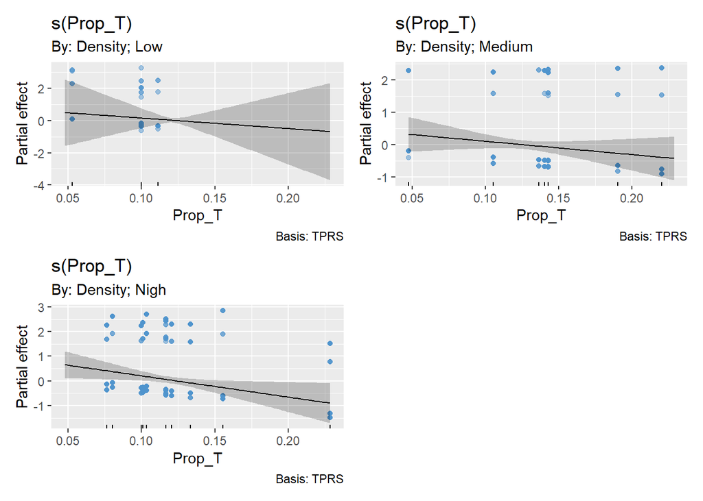

## Вероятность гибели мидий в зависимости от её местоположения

| term | estimate | std.error | statistic | p.value |
| --- | --- | --- | --- | --- |
| (Intercept) | 0.0549558 | 0.0103778 | 5.295494 | 0.0000001 |
| SubstrateBottom | 0.3660968 | 0.0195641 | 18.712718 | 0.0000000 |
| MorphotypeT | 0.0514271 | 0.0297664 | 1.727689 | 0.0842352 |
| SubstrateBottom:MorphotypeT | 0.1775202 | 0.0546827 | 3.246371 | 0.0011928 |

# Обсуждение результатов

Как показали предыдущие работы (Katolikova et al. 2016), *Mytilus edulis* (E-морфотип) чаще встречается на дне, тогда как *M. trossulus* (T-морфотип) - на фукоидах. Эту закономерность можно объяснить двумя способами. Во-первых, *M. trossulus* могут предпочитать селиться на фукоидах, а, во-вторых, такое распределение может быть следствием разделение ниш вследствие конкуренции. Во втором случае распределение видов по двум микробиотопам должно зависеть от плотности поселения. Ожидается, что разделение ниш будет наиболее ярко выражено при высокой плотности поселения. В нашем исследовании мы постаралиь смоделировать этот процесс. Однако значимой связи корреляции сегрегации мидий по субстратам с плотностью поселения мы не обнаружили. Однако, нами было замечено, что при средней и высокой плотности поселения вероятность ухода мидии с донной части садка на водоросли начинает зависеть от таксономического состава поселения (доли T-морфотипа). Чем больше в поселении особей T-морфотипа тем с большей вероятностью моллюски мигрируют на водоросли.

Полученные данные можно трактовать двумя способами. Гипотеза 1: выявленная закономерность может быть следствием того, что в поселениях высокой плотности при увеличении доли Т-морфотипа происходит более активное вытеснение мидий на фукоиды. Известно, что в смешанных поселениях двух видов мидий, по мере увеличения плотности, как следствие конкурентных отношений, увеличивается смертность обоих видов (Шилонцев 2022). Можно предположить, что и в нашем случае при высокой плотности и высокой доле T-морфотипа возникают неблагоприятные условия, которые заставляют мидий мигрировать на водоросли. На поверхности фукоидов могут формироваться более разреженные поселения, вследствие большей площади субстарта.

Гипотеза 2: это наблюдаемый паттерн может быть объяснен разной численностью Т-морфотипа в садках с разной плотностью. Так, например, в поселениях с маленькой плотностью количество мидий Т-морфотипа может быть недостаточным для выявления статистически значимой связи с таксономической структурой. Таким образом, связь вероятности перехода с донной части на водоросли с таксономической структурой поселений может быть не замеченной при низком обилии моллюсков. Если это так, то можно предположить, что наблюдаемая связь вероятности перехода на водоросли с таксономической структурой поселения является следствием того, что мидии T-морфотипа более активно переходят на водоросли, чем мидии E-морфотипа. Это хорошосогласуется с тем фактом, что *M.edulis* (Е-морфотип) имеют более толстую и тяжелую раковину (Beaumont et al. 2008), а, следовательно, активность их перемещение будет ниже. Более легкие и более подвижные *M.trossulus* (T-морфотип) могут активнее заползать на фукоиды, что и определяет увеличение вероятности перехода на водоросли при увеличении доли Т-морфотипа.

Если вторая гипотеза верна, то можно ожидать, что степень различия доли T-морфотипа на дне садка и на фукоидах должна быть более или менее постоянной в садках всех типов вне зависиомсти от плотности поселения. Степень различия доли T-морфотипа мы оценивали с помощью величины Dif. Мы обнаружили, что эта величина закономерно изменяется: в садках с высокой плотностью поселеиня Diff линейно увеличивается по мере роста доли T-морфотипа. Это можно трактовать как вытеснение Т-морфотипа на фукоиды. Это лучше согласуется с первой гипотезой и указывает на присутствие конкуренции в поселении, которая заставляет перераспределяться мидий.

Уменьшение смертности в поселениях с высокой долей Т-морфотипа входит в противоречие с литературными данными (Шилонцев 2022, Ковалев 2023), где было показано, что в смешанных поселениях, в которых преобладают мидии Т-морфотипа, смертность моллюсков повышается. Однако в обеих процитированных работах изучались поселения на грунте. В таких поселениях моллюски находятся в более или менее одной плоскости. В такой ситуации мидии могут негативно влиять на своих седей. Если же рядом присутствуют водоросли, то появляется дополнительный субстрат, который позволяет мидиям разойтись в трехмерном пространстве. В результате этого мидии, переместившиеся на водоросли избегают скоплений, что позволяет снизить конкуренцию и, таким образом, уменьшить смертность.

# Заключение

Основной идеей работы бвло смоделировать условия, в которых можно было бы проверить гипотезу о влиянии конкуренции на расхождение двух видов мидий по микробиотопам (грунт vs водоросли). Мы смогли решить эту задачу лишь частично. Мы показали, что на дне смертность моллюсков больше, чем на водорослях. Мы также показали, что мидии активно перемещаются на фукоиды и при этом вероятность данного перемещения коррелирует с таксономическим составом смешанного поселения. Однако непосредственной роли плотности поселения, как причины такого перемещения, нам выявить не удалось. Кроме того, полностью смоделировать распределение видов, когда на фукоидах преобладает *Mytilus trossulus*, а на субстрате *M. edulis*, нам также не удалось. В дальнейшем понадобятся дополнительные исследования для более детальной проверки гипотез.

# Благодарности

Хочется выразить благодарность Вадиму Михайловичу Хайтову как научному руководителю, а так же Кандалакшскому заповеднику за возможность работы и LVIII Беломорской экспедиции. Особо я признательнв своему руководителю В. М. Хайтову.

# Литература

Beaumont AR, Hawkins MP, Doig FL, Davies IM, Snow M (2008) Three Species of Mytilus and Their Hybrids Identified in a Scottish Loch: Natives, Relicts and Invaders? Journal of Experimental Marine Biology and Ecology 367:100–110.

Gause G (1934) The struggle for existence.

Katolikova M, Khaitov V, Väinölä R, Gantsevich M, Strelkov P (2016) Genetic, ecological and morphological distinctness of the blue mussels Mytilus trossulus Gould and M. edulis L. in the White Sea. PLoS One 11:e0152963.

Khaitov V, Marchenko J, Katolikova M, Väinölä R, Kingston SE, Carlon DB, Gantsevich M, Strelkov P (2021) Species identification based on a semi-diagnostic marker: Evaluation of a simple conchological test for distinguishing blue mussels Mytilus edulis L. and M. trossulus Gould. Plos one 16:e0249587.

Буфалова Е, Стрелков П, Католикова М, Сухотин А, Козин М (2005) Мидии p. Mytilus Губы Тюва (Кольский Залив, Баренцево Море). Biological Communications:99–105.

Ковалев АА (2023) Физиологические различия криптических видов р. Mytilus в условиях совместных поселений.

Хлебосолов Е (2002) Теория Экологической Ниши: История и Современное Состояние. Русский орнитологический журнал 11:1019–1037.

Шеламова В (2023) Биссус, как средство подавления конкурнетов у беломорских мидий Mytilus edulis Linnaeus, 1758 и M. trossulus Gould, 1850.

Шеламова В (2022) Механизм конкуренции мидий Mytilus edulis Linnaeus, 1758 и M. trossulus Gould, 1850.

Шилонцев А (2022) Исследование конкурентных отношений беломорских мидий Mytilus edulis и M.trossгlus.